# Chapter 6 - Learning Best Practices for Model Evaluation and Hyperparameter Tuning

### Overview

- Streamlining workflows with pipelines
  - Loading the Breast Cancer Wisconsin dataset
  - Combining transformers and estimators in a pipeline
- Using k-fold cross-validation to assess model performance
  - The holdout method
  - K-fold cross-validation
- Debugging algorithms with learning and validation curves
  - Diagnosing bias and variance problems with learning curves
  - Addressing overfitting and underfitting with validation curves
- Fine-tuning machine learning models via grid search
  - Tuning hyperparameters via grid search
  - Algorithm selection with nested cross-validation
- Looking at different performance evaluation metrics
  - Reading a confusion matrix
  - Optimizing the precision and recall of a classification model
  - Plotting a receiver operating characteristic
  - The scoring metrics for multiclass classification
- Summary

```python
from IPython.display import Image
%matplotlib inline
```

# Streamlining workflows with pipelines

## Loading the Breast Cancer Wisconsin dataset

```python
import pandas as pd
import urllib

try:
    df = pd.read_csv('https://archive.ics.uci.edu/ml/machine-learning-databases'
                     '/breast-cancer-wisconsin/wdbc.data', header=None)

except urllib.error.URLError:
    df = pd.read_csv('https://raw.githubusercontent.com/rasbt/'
                     'python-machine-learning-book/master/code/'
                     'datasets/wdbc/wdbc.data', header=None)

print('rows, columns:', df.shape)
df.head()
```

```
rows, columns: (569, 32)
```

|  | 0 | 1 | 2 | 3 | 4 | 5 | 6 | 7 | 8 | 9 | ... | 22 | 23 | 24 | 25 | 26 | 27 | 28 | 29 | 30 | 31 |
| --- | --- | --- | --- | --- | --- | --- | --- | --- | --- | --- | --- | --- | --- | --- | --- | --- | --- | --- | --- | --- | --- |
| 0 | 842302 | M | 17.99 | 10.38 | 122.80 | 1001.0 | 0.11840 | 0.27760 | 0.3001 | 0.14710 | ... | 25.38 | 17.33 | 184.60 | 2019.0 | 0.1622 | 0.6656 | 0.7119 | 0.2654 | 0.4601 | 0.11890 |
| 1 | 842517 | M | 20.57 | 17.77 | 132.90 | 1326.0 | 0.08474 | 0.07864 | 0.0869 | 0.07017 | ... | 24.99 | 23.41 | 158.80 | 1956.0 | 0.1238 | 0.1866 | 0.2416 | 0.1860 | 0.2750 | 0.08902 |
| 2 | 84300903 | M | 19.69 | 21.25 | 130.00 | 1203.0 | 0.10960 | 0.15990 | 0.1974 | 0.12790 | ... | 23.57 | 25.53 | 152.50 | 1709.0 | 0.1444 | 0.4245 | 0.4504 | 0.2430 | 0.3613 | 0.08758 |
| 3 | 84348301 | M | 11.42 | 20.38 | 77.58 | 386.1 | 0.14250 | 0.28390 | 0.2414 | 0.10520 | ... | 14.91 | 26.50 | 98.87 | 567.7 | 0.2098 | 0.8663 | 0.6869 | 0.2575 | 0.6638 | 0.17300 |
| 4 | 84358402 | M | 20.29 | 14.34 | 135.10 | 1297.0 | 0.10030 | 0.13280 | 0.1980 | 0.10430 | ... | 22.54 | 16.67 | 152.20 | 1575.0 | 0.1374 | 0.2050 | 0.4000 | 0.1625 | 0.2364 | 0.07678 |

5 rows × 32 columns

```python
df.shape
```

```
(569, 32)
```

```python
from sklearn.preprocessing import LabelEncoder

X = df.loc[:, 2:].values
y = df.loc[:, 1].values
le = LabelEncoder()
y = le.fit_transform(y)
le.transform(['M', 'B'])   # M=malignant, B=benign
```

```
array([1, 0])
```

```python
from sklearn.model_selection import train_test_split

X_train, X_test, y_train, y_test = \
    train_test_split(X, y, test_size=0.20, random_state=1)
```

## Combining transformers and estimators in a pipeline

```python
from sklearn.preprocessing import StandardScaler
from sklearn.decomposition import PCA
from sklearn.linear_model import LogisticRegression
from sklearn.pipeline import Pipeline

pipe_lr = Pipeline([('scl', StandardScaler()),
                    ('pca', PCA(n_components=2)),
                    ('clf', LogisticRegression(random_state=1))])

pipe_lr.fit(X_train, y_train)
print('Test Accuracy: %.3f' % pipe_lr.score(X_test, y_test))
y_pred = pipe_lr.predict(X_test)
```

```
Test Accuracy: 0.947
```

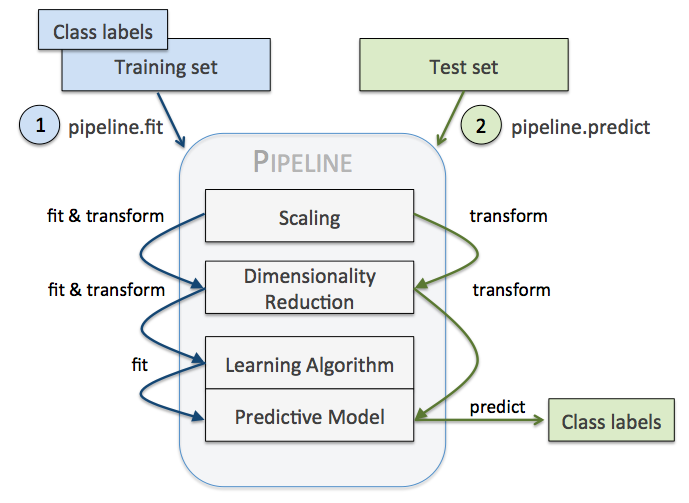

```python
Image(filename='./images/06_01.png', width=500)
```

# Using k-fold cross validation to assess model performance

Cross validation (CV) techniques:

- holdout CV
- k-fold CV

CV can help us to obtain reliable estimates of the model's generalization error, and use the estimates to tune hyperparameters.

## The holdout method

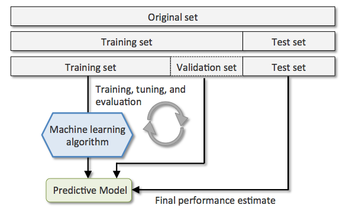

```python
Image(filename='./images/06_02.png', width=500)
```

- Training set: used to fit different models
- Validation set: used for model selection (hyperparameter tuning)
- Test set: used to estimate model's generalization error. Since we want to have less biased estimates, test set should be untouched in learning phase.

#### Disadvantage of holdout CV

- the performance estiamte on the validation set is sensitive to how we partition the training set into the training and validation subsets.

## K-fold cross-validation

We randomly split the training set into $k$ folds **without** replacement.

- Use $k-1$ folds as the training subset
- Use one fold as the validation set

Repeat $k$ times

We report the average performance of the models based on different, independent folds.

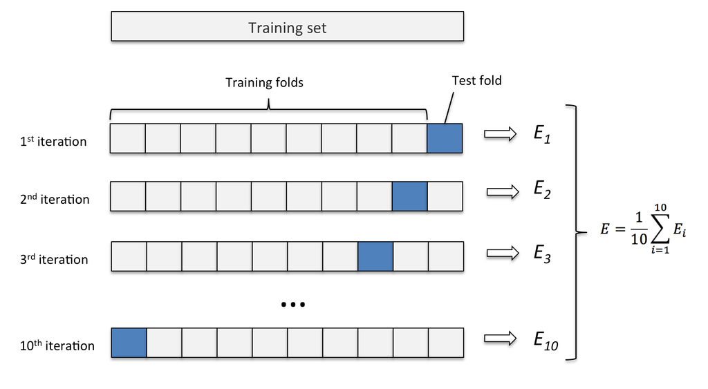

```python
Image(filename='./images/06_03.png', width=500)
```

- For small datasets, use larger values of $k$ (e.g., $k=25$):
  - More training data will be used in each iteration
  - Less bias towards estimating the generalization performace by averaging many individual model estimates
  - Larger runtime
  - LOO (leave-one-out) CV: $k=n$, $n$ is the number of training examples
- For large datasets, use smaller values of $k$ (e.g., $k=5$)

#### Stratified k-fold CV [R. Kohavi et al., 1995]

- Better when the class proportions are not equal

```python
import numpy as np

from sklearn.model_selection import StratifiedKFold

kfold = StratifiedKFold(n_splits=10,
                        random_state=1).split(X_train, y_train)

scores = []
for k, (train, test) in enumerate(kfold):
    pipe_lr.fit(X_train[train], y_train[train])
    score = pipe_lr.score(X_train[test], y_train[test])
    scores.append(score)
    print('Fold: %s, Class dist.: %s, Acc: %.3f' % (k+1,
          np.bincount(y_train[train]), score))

print('\nCV accuracy: %.3f +/- %.3f' % (np.mean(scores), np.std(scores)))
```

```
Fold: 1, Class dist.: [256 153], Acc: 0.891
Fold: 2, Class dist.: [256 153], Acc: 0.978
Fold: 3, Class dist.: [256 153], Acc: 0.978
Fold: 4, Class dist.: [256 153], Acc: 0.913
Fold: 5, Class dist.: [256 153], Acc: 0.935
Fold: 6, Class dist.: [257 153], Acc: 0.978
Fold: 7, Class dist.: [257 153], Acc: 0.933
Fold: 8, Class dist.: [257 153], Acc: 0.956
Fold: 9, Class dist.: [257 153], Acc: 0.978
Fold: 10, Class dist.: [257 153], Acc: 0.956

CV accuracy: 0.950 +/- 0.029
```

```python
from sklearn.model_selection import cross_val_score

scores = cross_val_score(estimator=pipe_lr,
                         X=X_train,
                         y=y_train,
                         cv=10,
                         n_jobs=1)  # no. cpu cores to use. -1 all cores
print('CV accuracy scores: %s' % scores)
print('CV accuracy: %.3f +/- %.3f' % (np.mean(scores), np.std(scores)))
```

```
CV accuracy scores: [ 0.89130435  0.97826087  0.97826087  0.91304348  0.93478261  0.97777778
  0.93333333  0.95555556  0.97777778  0.95555556]
CV accuracy: 0.950 +/- 0.029
```

#### Further readings

- M. Markatou, H. Tian, S. Biswas, and G. M. Hripcsak. Analysis of Variance of Cross-validation Estimators of the Generalization Error. Journal of Machine Learning Research, 6:1127–1168, 2005
- B. Efron and R. Tibshirani. Improvements on Cross-validation: The 632+ Bootstrap Method. Journal of the American Statistical Association, 92(438):548–560, 1997

# Debugging algorithms with learning curves

## Diagnosing bias and variance problems with learning curves

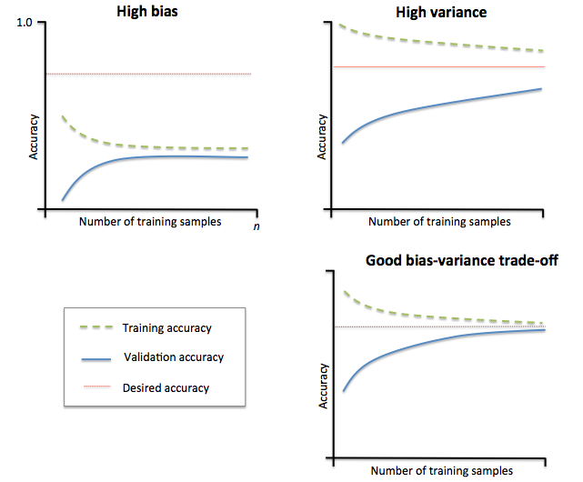

```python
Image(filename='./images/06_04.png', width=600)
```

#### Top-Left (underfitting)

- High bias
- Low training and low validation accuracy
- The model may underfit the training data
- Increase model's complexity (no. of parameters)
- Decrease regularization

#### Top-Right (Overfitting)

- High variance
- High training and low validation accuracy
- The model may overfit the training data
- Decrease model's complexity (e.g. by feature selection or feature extraction)
- Increase regularization

#### Learning curves in scikit-learn

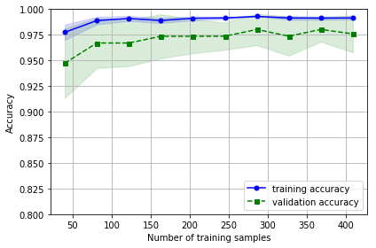

```python
import matplotlib.pyplot as plt

from sklearn.model_selection import learning_curve


pipe_lr = Pipeline([('scl', StandardScaler()),
                    ('clf', LogisticRegression(penalty='l2', random_state=0))])

train_sizes, train_scores, test_scores =\
                learning_curve(estimator=pipe_lr,
                               X=X_train,
                               y=y_train,
                               train_sizes=np.linspace(0.1, 1.0, 10),  # 10 evenly-spaced intervals
                               cv=10,  # 10-fold stratified CV
                               n_jobs=1)

train_mean = np.mean(train_scores, axis=1)
train_std = np.std(train_scores, axis=1)
test_mean = np.mean(test_scores, axis=1)
test_std = np.std(test_scores, axis=1)

plt.plot(train_sizes, train_mean,
         color='blue', marker='o',
         markersize=5, label='training accuracy')

plt.fill_between(train_sizes,
                 train_mean + train_std,
                 train_mean - train_std,
                 alpha=0.15, color='blue')

plt.plot(train_sizes, test_mean,
         color='green', linestyle='--',
         marker='s', markersize=5,
         label='validation accuracy')

plt.fill_between(train_sizes,
                 test_mean + test_std,
                 test_mean - test_std,
                 alpha=0.15, color='green')

plt.grid()
plt.xlabel('Number of training samples')
plt.ylabel('Accuracy')
plt.legend(loc='lower right')
plt.ylim([0.8, 1.0])
plt.tight_layout()
# plt.savefig('./figures/learning_curve.png', dpi=300)
plt.show()
```

In the above plot, the model performs pretty good but may overfit the training set, seeing from the gap between the trainina and the validation accuracy.

## Addressing over- and underfitting with validation curves

Validation curves can be used to tune the hyperparameters

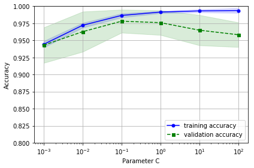

```python
from sklearn.model_selection import validation_curve

param_range = [0.001, 0.01, 0.1, 1.0, 10.0, 100.0]
train_scores, test_scores = validation_curve(
                estimator=pipe_lr,
                X=X_train,
                y=y_train,
                param_name='clf__C',
                param_range=param_range,
                cv=10)

train_mean = np.mean(train_scores, axis=1)
train_std = np.std(train_scores, axis=1)
test_mean = np.mean(test_scores, axis=1)
test_std = np.std(test_scores, axis=1)

plt.plot(param_range, train_mean,
         color='blue', marker='o',
         markersize=5, label='training accuracy')

plt.fill_between(param_range, train_mean + train_std,
                 train_mean - train_std, alpha=0.15,
                 color='blue')

plt.plot(param_range, test_mean,
         color='green', linestyle='--',
         marker='s', markersize=5,
         label='validation accuracy')

plt.fill_between(param_range,
                 test_mean + test_std,
                 test_mean - test_std,
                 alpha=0.15, color='green')

plt.grid()
plt.xscale('log')
plt.legend(loc='lower right')
plt.xlabel('Parameter C')
plt.ylabel('Accuracy')
plt.ylim([0.8, 1.0])
plt.tight_layout()
# plt.savefig('./figures/validation_curve.png', dpi=300)
plt.show()
```

C is the inverse of the regularization parameter:

- Small C (large regularization): underfitting
- Large C (small regularization): overfitting

The sweet spot is around C=0.1

# Fine-tuning machine learning models via grid search

There can be multiple hyperparameters. We tune joint settings of these hyperparameters using grid search.

## Tuning hyperparameters via grid search

```python
from sklearn.svm import SVC
from sklearn.model_selection import GridSearchCV

pipe_svc = Pipeline([('scl', StandardScaler()),
            ('clf', SVC(random_state=1))])

param_range = [0.0001, 0.001, 0.01, 0.1, 1.0, 10.0, 100.0, 1000.0]

param_grid = [{'clf__C': param_range,
               'clf__kernel': ['linear']},
               {'clf__C': param_range,
               'clf__gamma': param_range,
               'clf__kernel': ['rbf']}]

gs = GridSearchCV(estimator=pipe_svc,
                  param_grid=param_grid,
                  scoring='accuracy',
                  cv=10,
                  n_jobs=-1)
gs = gs.fit(X_train, y_train)
print(gs.best_score_)
print(gs.best_params_)
```

```
0.978021978022
{'clf__C': 0.1, 'clf__kernel': 'linear'}
```

```python
clf = gs.best_estimator_
clf.fit(X_train, y_train)
print('Test accuracy: %.3f' % clf.score(X_test, y_test))
```

```
Test accuracy: 0.965
```

An alternative: RandomizedSearchCV

## Algorithm selection with nested cross-validation

Good for comparing different machine learning models

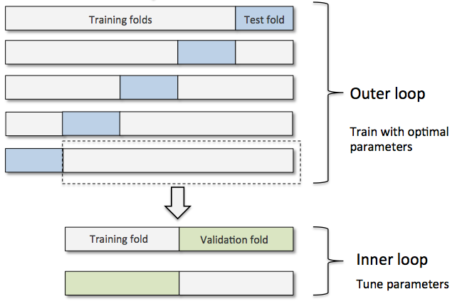

```python
Image(filename='./images/06_07.png', width=500)
```

```python
gs = GridSearchCV(estimator=pipe_svc,
                  param_grid=param_grid,
                  scoring='accuracy',
                  cv=2)

# Note: Optionally, you could use cv=2
# in the GridSearchCV above to produce
# the 5 x 2 nested CV that is shown in the figure.

scores = cross_val_score(gs, X_train, y_train, scoring='accuracy', cv=5)
print('CV accuracy: %.3f +/- %.3f' % (np.mean(scores), np.std(scores)))
```

```
CV accuracy: 0.965 +/- 0.025
```

```python
from sklearn.tree import DecisionTreeClassifier

gs = GridSearchCV(estimator=DecisionTreeClassifier(random_state=0),
                  param_grid=[{'max_depth': [1, 2, 3, 4, 5, 6, 7, None]}],
                  scoring='accuracy',
                  cv=2)
scores = cross_val_score(gs, X_train, y_train, scoring='accuracy', cv=5)
print('CV accuracy: %.3f +/- %.3f' % (np.mean(scores), np.std(scores)))
```

```
CV accuracy: 0.921 +/- 0.029
```

# Looking at different performance evaluation metrics

## Reading a confusion matrix

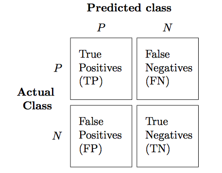

```python
Image(filename='./images/06_08.png', width=300)
```

```python
from sklearn.metrics import confusion_matrix

pipe_svc.fit(X_train, y_train)
y_pred = pipe_svc.predict(X_test)
confmat = confusion_matrix(y_true=y_test, y_pred=y_pred)
print(confmat)
```

```
[[71  1]
 [ 2 40]]
```

### Additional Note

Remember that we previously encoded the class labels so that *malignant* samples are the **"postive" class (1)**, and *benign* samples are the **"negative" class (0)**:

```python
le.transform(['M', 'B'])
```

```
array([1, 0])
```

```python
confmat = confusion_matrix(y_true=y_test, y_pred=y_pred)
print(confmat)
```

```
[[71  1]
 [ 2 40]]
```

Next, we printed the confusion matrix like so:

```python
confmat = confusion_matrix(y_true=y_test, y_pred=y_pred)
print(confmat)
```

```
[[71  1]
 [ 2 40]]
```

Note that the (true) class 0 samples that are correctly predicted as class 0 (true negatives) are now in the upper left corner of the matrix (index 0, 0). In order to change the ordering so that the true negatives are in the lower right corner (index 1,1) and the true positves are in the upper left, we can use the `labels` argument like shown below:

```python
confmat = confusion_matrix(y_true=y_test, y_pred=y_pred, labels=[1, 0])
print(confmat)
```

```
[[40  2]
 [ 1 71]]
```

## Optimizing the precision and recall of a classification model

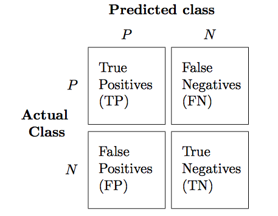

```python
Image(filename='./images/06_08.png', width=300)
```

In the cancer data example:

- Positive (1, Malignant)
- Negative (0, Benign)
- TP: Actual M --> Predicted M
  - It's about detection of malignant tumors
  - Higher is better
- FP: Actual B --> Predicted M
  - It's about false alarm
  - Lower is better

#### Accuracy (ACC):

$$ ACC = \frac{\text{Correct}}{\text{ALL}} = \frac{TP+TN}{ALL} = 1 - ERR $$

#### True positive rate (TPR):

$$ TPR = \frac{TP}{Actual \; P} = \frac{TP}{TP+FN} $$

#### False positive rate (FPR):

$$ FPR = \frac{FP}{Actual \; N} = \frac{FP}{FP+TN} $$

#### Precision (PRE):

$$ PRE = \frac{TP}{Predicted \; P} = \frac{TP}{TP + FP} $$

#### Recall (REC)

$$ REC = TPR = \frac{TP}{Actual \; P} = \frac{TP}{TP+FN} $$

#### F1 score

The harmonic mean of precision and recall $$ F1 = 2 \frac{PRE \times REC}{PRE + REC} $$

```python
from sklearn.metrics import precision_score, recall_score, f1_score

print('Precision: %.3f' % precision_score(y_true=y_test, y_pred=y_pred))
print('Recall: %.3f' % recall_score(y_true=y_test, y_pred=y_pred))
print('F1: %.3f' % f1_score(y_true=y_test, y_pred=y_pred))
```

```
Precision: 0.976
Recall: 0.952
F1: 0.964
```

```python
from sklearn.metrics import make_scorer

scorer = make_scorer(f1_score, pos_label=0)  # default positive label is 1

c_gamma_range = [0.01, 0.1, 1.0, 10.0]

param_grid = [{'clf__C': c_gamma_range,
               'clf__kernel': ['linear']},
              {'clf__C': c_gamma_range,
               'clf__gamma': c_gamma_range,
               'clf__kernel': ['rbf']}]

gs = GridSearchCV(estimator=pipe_svc,
                  param_grid=param_grid,
                  scoring=scorer,
                  cv=10,
                  n_jobs=-1)
gs = gs.fit(X_train, y_train)
print(gs.best_score_)
print(gs.best_params_)
```

```
0.982798668208
{'clf__C': 0.1, 'clf__kernel': 'linear'}
```

## Plotting a receiver operating characteristic (ROC)

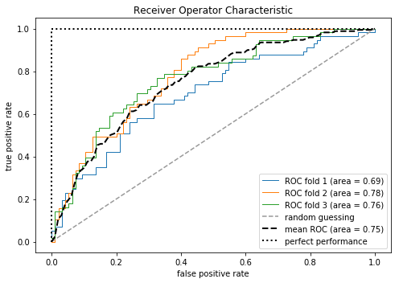

```python
from sklearn.metrics import roc_curve, auc
from scipy import interp

pipe_lr = Pipeline([('scl', StandardScaler()),
                    ('pca', PCA(n_components=2)),
                    ('clf', LogisticRegression(penalty='l2',
                                               random_state=0,
                                               C=100.0))])

X_train2 = X_train[:, [4, 14]]

cv = list(StratifiedKFold(n_splits=3,
                          random_state=1).split(X_train, y_train))

fig = plt.figure(figsize=(7, 5))

mean_tpr = 0.0
mean_fpr = np.linspace(0, 1, 100)
all_tpr = []

for i, (train, test) in enumerate(cv):
    probas = pipe_lr.fit(X_train2[train],
                         y_train[train]).predict_proba(X_train2[test])

    fpr, tpr, thresholds = roc_curve(y_train[test],
                                     probas[:, 1],
                                     pos_label=1)
    mean_tpr += interp(mean_fpr, fpr, tpr)
    mean_tpr[0] = 0.0
    roc_auc = auc(fpr, tpr)
    plt.plot(fpr,
             tpr,
             lw=1,
             label='ROC fold %d (area = %0.2f)'
                   % (i+1, roc_auc))

plt.plot([0, 1],
         [0, 1],
         linestyle='--',
         color=(0.6, 0.6, 0.6),
         label='random guessing')

mean_tpr /= len(cv)
mean_tpr[-1] = 1.0
mean_auc = auc(mean_fpr, mean_tpr)
plt.plot(mean_fpr, mean_tpr, 'k--',
         label='mean ROC (area = %0.2f)' % mean_auc, lw=2)
plt.plot([0, 0, 1],
         [0, 1, 1],
         lw=2,
         linestyle=':',
         color='black',
         label='perfect performance')

plt.xlim([-0.05, 1.05])
plt.ylim([-0.05, 1.05])
plt.xlabel('false positive rate')
plt.ylabel('true positive rate')
plt.title('Receiver Operator Characteristic')
plt.legend(loc="lower right")

plt.tight_layout()
# plt.savefig('./figures/roc.png', dpi=300)
plt.show()
```

```python
thresholds
```

```
array([ 0.84490146,  0.8070536 ,  0.67480805,  0.66253136,  0.64732616,
        0.63111116,  0.62041242,  0.61571257,  0.59013169,  0.58046991,
        0.56704548,  0.56310957,  0.56071956,  0.55966358,  0.55498341,
        0.54310714,  0.53641671,  0.52405505,  0.49379657,  0.4852618 ,
        0.46811966,  0.46779467,  0.46628032,  0.46217493,  0.45027354,
        0.43920702,  0.43908893,  0.43799828,  0.42901345,  0.4218405 ,
        0.40082846,  0.396146  ,  0.39226753,  0.38492126,  0.37633152,
        0.370179  ,  0.36999606,  0.35599018,  0.35104901,  0.34451701,
        0.34439511,  0.32599645,  0.32254307,  0.31724248,  0.30647585,
        0.27380594,  0.26537881,  0.26364877,  0.25554201,  0.24845629,
        0.24426422,  0.24094915,  0.23468273,  0.22923588,  0.22781819,
        0.20321836,  0.20267315,  0.17857041,  0.17283522,  0.1534203 ,
        0.15083836,  0.03923762])
```

```python
pipe_lr = pipe_lr.fit(X_train2, y_train)
y_labels = pipe_lr.predict(X_test[:, [4, 14]])
y_probas = pipe_lr.predict_proba(X_test[:, [4, 14]])[:, 1]
# note that we use probabilities for roc_auc
# the `[:, 1]` selects the positive class label only
```

```python
from sklearn.metrics import roc_auc_score, accuracy_score
print('ROC AUC: %.3f' % roc_auc_score(y_true=y_test, y_score=y_probas))
print('Accuracy: %.3f' % accuracy_score(y_true=y_test, y_pred=y_labels))
```

```
ROC AUC: 0.752
Accuracy: 0.711
```

## The scoring metrics for multiclass classification

We've done multiclass classification via One-vs-All (OvA).

For multiclass classification, we define **micro** and **macro** performance measures.

For example, for a $k$-class problem,

#### Micro-score:

$$ PRE_{micro} = \frac{TP_1 + \dots + TP_k}{TP_1 + \dots + TP_k + FP_1 + \dots + FP_k} $$

#### Macro-score:

$$ PRE_{macro} = \frac{PRE_1 + \dots + PRE_k}{k} $$

In scikit-learn, if we use binary performance metric for multiclass classification, a *weighted* variant of macro-score is used by default, where the weights are the number of true instances in each class. This is better when the number of instances for each label is different.

```python
pre_scorer = make_scorer(score_func=precision_score,
                         pos_label=1,
                         greater_is_better=True,
                         average='micro')
```